# Xing Ye

## Description Two

The image of free sulfur dioxide show approximately normal distribution with a little left skewed and the distribution of total sulfur dioxide is similar to the one of free sulfur dioxide.However, we should consider the range of x axis. The image show the different quality count in free sulfur dioxide and total sulfur dioxide and the colour don’t deepen as the values of x axis adding. But the distribution of higher quality trends to aggregating in the middle of the axis.

## Plot Three

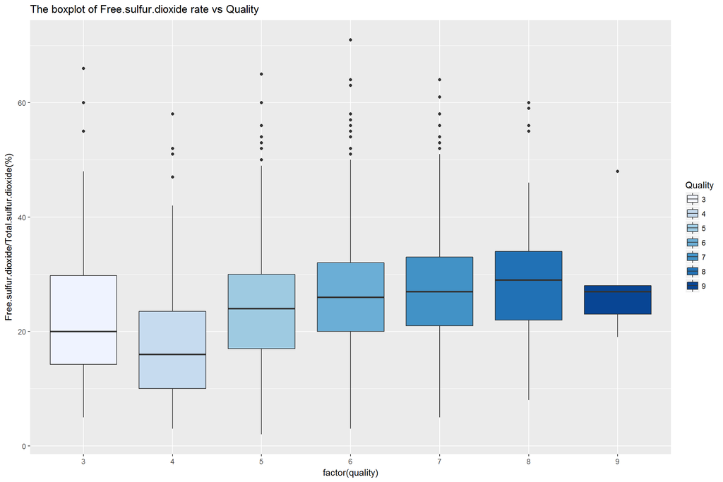

# Reflection

From the analyze the white wine dataset, we could find some interesting phenomenons while ploting some conditional figures. Our interested features are free sulfur dioxide and total sulfur dioxide. We can discover the amount of sulfur dioxide doesn’t impact quality strongly whatever the total sulfur dioxide or free sulfur dioxide. However, the high quality wine is prone to have a high free sulfur dioxide rate and distributes around the mean value in either sulfur dioxide .  
Considering the other features, according to the correlation coefficient matrix, we investigate the relation among density, residual sugar and alcohol. The three variances are related with each other strongly. Apart from that, The density also has a strong relation with total sulfur dioxide. For the powerful relation between residual sugar with density, We think the sugar has a large relative molecular mass compared to other composition in the wine. The same to total sulfur dioxide, the density increase while total sulfur dioxide adding. Then, We guess the free sulfur dioxide rate may related with sulphates. The result shows that we were wrong because of the correlation coefficient close to zero that signifies weak relation. Afterwards, we print the density diagram to view the distributions of free sulfur dioxide and total sulfur dioxide. The joint distribution map of the two variables is similar to the 3-D normal distribution. Finally, we check the boxplot of the free sulfur dioxide rate. During the analysis, the relation between different variables make us confused. The density connect to several variables and how the relations like among these variables doesn’t explore. The research isn’t fully investigating and it still has some questions to analyze.For example, whether the relation between alcohol and density is a coincide or something need to study.